# Tutorial doublIn package

Vera Arntzen

2024-04-03

First, we load the package doublIn.

```r
# Load the package.
library(doublIn)
```

### Estimate latency time

Before we start, let’s generate a simple data set.

```r
# The random starting point can be changed to another value if you like.
set.seed(123)

# For details, see the example in the help file of the function Estimate_doublIn.
  L1 <- sample(1:5, 100, replace = T)
  L <- runif(100, 0, L1)
  times <- rgamma(100, shape = 4.05, rate = 0.74)
  R <- L + times
  R0 <- floor(R); R1 <- floor(R + 1)
  L1 <- ifelse(L1 > R1, R1, L1)
  Q <- L1 + sample( c(5, 10, 15, 20, 25), 100, replace = T)
  mydat <- data.frame(R = R, L0 = 0, L1 = L1, R0 = R0, R1 = R1,
                      Trunc = Q)
  mydat <- mydat[which( (mydat$R > mydat$Trunc) == F), ]
  mydat$R <- NULL
  rownames(mydat) <- NULL

# Inspect the data.
  knitr::kable(head(mydat, 5))
```

| L0 | L1 | R0 | R1 | Trunc |
| --- | --- | --- | --- | --- |
| 0 | 3 | 3 | 4 | 18 |
| 0 | 3 | 6 | 7 | 23 |
| 0 | 2 | 2 | 3 | 22 |
| 0 | 2 | 7 | 8 | 17 |
| 0 | 3 | 13 | 14 | 23 |

The example data is based on the structure of real observations of the latency time, but may be used to illustrate the analysis for any doubly interval censored time-to-event (L to R). Therefore, in the remainder of this tuturial we use the notation L and R instead of E (infection/exposure) and S (symptom onset/start-of-shedding).

The data set has five columns that define the exposure window (L0; L1), the start-of-shedding window (R0; R1) and the truncation time. The truncation time does not have to be part of the data set necessarily. It is only required when truncation is addressed during the analysis, as we will see later.

Each cell represents the number of days elapsed since the start of exposure, which is L0 (0 is this case) but this may be since any calendar time, and in a measurement unit that the user prefers.

In the analysis, we take the following factors into account, which is important to obtain unbiased estimates: (i) the infection risk within the exposure window (exponential growth); (ii) the under-representation of long latency times (right truncation); (iii) the potentially longtailed latency time distribution, requiring a flexible model (generalized gamma). The factors that are relevant depend from context to context.

For now, we assume that the risk of infection remained constant during the fictive outbreak. We come back to (i) in the second part of this tutorial.

```r
# Run the model with truncation.
out_list  <- Estimate_doublIn(dat = mydat,
             infection_risk_distribution = "constant",
             method = "gamma", percentiles = c(0.5, 0.9, 0.95, 0.99),
             right_truncation = T, iters = 1000,
             burnin_period = 10, thin = 1,
             further_thin_plots = 1,
             plot_rm_burnin = T)
# Inspect the output.
summary(out_list)
```

```
#>                        Length Class      Mode
#> estimates              10     data.frame list
#> plot_running_quantiles  9     gg         list
#> plot_parameters         9     gg         list
```

The output is a list with three components: a data.frame with the estimates; a diagnostic plot of the quantiles; a diagnostic plot of the parameters.

```r
# Inspect the estimates.
knitr::kable(out_list$estimates)
```

|  | est | lower_CI | upper_CI | par | iters | thinning | burnin_period | f | g | right_truncation |
| --- | --- | --- | --- | --- | --- | --- | --- | --- | --- | --- |
| theta | 1.151373 | 0.7388587 | 1.794394 | theta | 1000 | 1 | 10 | gamma | constant | TRUE |
| kappa | 4.470885 | 3.0217032 | 6.805943 | kappa | 1000 | 1 | 10 | gamma | constant | TRUE |
| delta | 1.000000 | 1.0000000 | 1.000000 | delta | 1000 | 1 | 10 | gamma | constant | TRUE |
| mean | 5.154868 | 4.6062243 | 5.854882 | mean | 1000 | 1 | 10 | gamma | constant | TRUE |
| variance | 5.926442 | 3.6720793 | 9.960792 | variance | 1000 | 1 | 10 | gamma | constant | TRUE |
| 0.5 | 4.772929 | 4.2384939 | 5.373800 | 0.5 | 1000 | 1 | 10 | gamma | constant | TRUE |
| 0.9 | 8.402811 | 7.3685454 | 9.897148 | 0.9 | 1000 | 1 | 10 | gamma | constant | TRUE |
| 0.95 | 9.699733 | 8.3908732 | 11.625889 | 0.95 | 1000 | 1 | 10 | gamma | constant | TRUE |
| 0.99 | 12.429447 | 10.4820913 | 15.411251 | 0.99 | 1000 | 1 | 10 | gamma | constant | TRUE |
| Gelman diag.: lambda_gg | 1.066234 | NA | 1.138211 | Gelman diag.: lambda_gg | 1000 | 1 | 10 | gamma | constant | TRUE |
| Gelman diag.: r | 1.068361 | NA | 1.144237 | Gelman diag.: r | 1000 | 1 | 10 | gamma | constant | TRUE |

### Visualize the results

Let’s plot the estimated distribution.

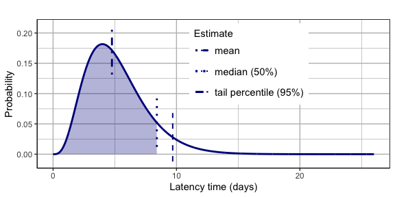

```r
# Make a function of the plot in the paper.
Plot_doublIn(doublIn_obj = out_list,
             label_x = "Latency time (days)",
             label_y = "Probability")
```

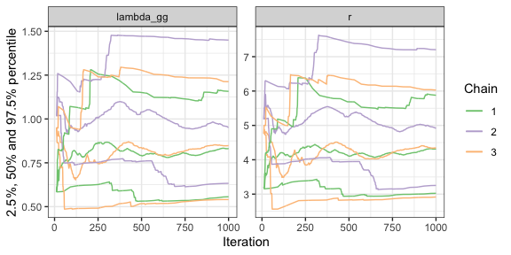

```r
# Plot the running quantiles.
out_list$plot_running_quantiles
```

Each color represents one of the three Markov Monte Carlo chains. Essentially, the model starts at three random points. The model converged properly if the quantiles (2.5%, 50%, 97.5%) of the parameters using all iterations up to the respective iteration (omitting the burnin period) overlap almost entirely on the right side of the plot. So, if all is well, we observe three bundles with each three lines of a different color.

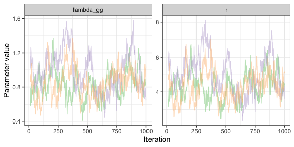

```r
# Plot the parameter values per iteration.
out_list$plot_parameters
```

Instead of a cumulative measure, the second plot represents the parameter values at each iteration. When mixing is properly, there is no pattern visible; just a blur. When, for example, the first 200 iterations the values are clearly different from the remaining iterations, the burnin period needs to be longer.

### Estimate the exponential growth factor

To address (i), we need the exponential growth factor for our specific sampling period and place. To this end, in the analysis for our paper on SARS-CoV-2 latency time we utilized time series of the incidence of individuals with a first positive test from an extensive line list. However, for illustration purposes, we use openly available data from the R package ‘outbreaks’, concerning the daily incidence of influenza cases in a boarding school in England. We use the R package ‘incidence’ to obtain the estimate of the exponential growth factor r.

```r
# Load the package.
require(incidence)
require(outbreaks)
```

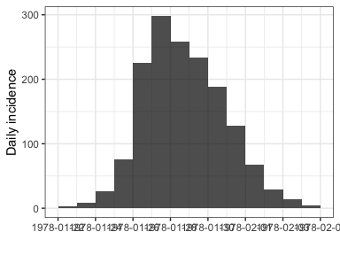

```r
data("influenza_england_1978_school")

# Format as an incidence object.
inc_obj <- as.incidence(influenza_england_1978_school$in_bed,
                      influenza_england_1978_school$date)
plot(inc_obj)
```

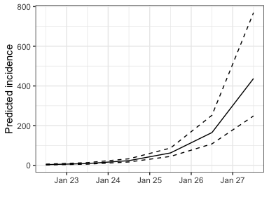

```r
# Find the peak.
peak <- find_peak(inc_obj)

# Select only the incidence up to the peak for estimation.
inc_obj <- inc_obj[inc_obj$dates <= peak,]

# Estimate the growth rate.
# We will only use the increasing phase for estimation, hence the term '-1'
inc_fit <- incidence::fit(inc_obj)
r <- inc_fit$info$r
plot(inc_fit)
```

```r
# Inspect r .
r
```

```
#> [1] 0.973572
```

Notice that influenza outbreaks tend to grow much faster than those of SARS-CoV-2 due to the short incubation and latency time.

### Explore the possibilities of the visualization app

```r
# Run the app
Visualize_contact_tracing_data()





```

Shiny applications not supported in static R Markdown documents

### References

Lessler J, Reich NG, Cummings DAT and The DOHMH Swine Influenza Investigation Team. Outbreak of 2009 Pandemic Influenza A (H1N1) at a New York City School. New England Journal of Medicine. 2009. 361(27):2628-2636.